# APL Individual project

Vitalii Fishchuk

2024-11-07

Disclaimer: AI has been used in this work. Purpose: inquiry instrument, fixing bugs, documentation reference. Model: ChatGPT-4o.

Disclaimer 2: Part of the code (mainly lasso) is based on the assignment 3 of our group, and that code was based on the lectures. You can find parts of the code almost identical, as I do not see the reason of writing stuff twice, rather adapting and incorporating feedback. However, just in case, i leave this remark here, so it is not counted as plagiarism (technically of my own work).

## Introduction

This project examines risk of heart diseases in relation to 11 predictors, hoping to establish clear causality and build an effective classification model, which would allow to pinpoint variables with the highest effect on the heart disease risk. This can later be used to provide medical recommendations based on the patients data and pinpoint heart diseases in the earlier stages. The expected use case is doctors using the model to assess probability of a patient having a heart disease right now (or in the near future), hence i do not select a classificaiton threshold, as the decission is made by the doctor. The model only shows probability of a heart disease, maximizing human autonomy and decision making, which is paramount in the healthcare industry.

# Dataset

The dataset for this project was obtained from Kaggle (https://www.kaggle.com/datasets/mexwell/heart-disease-dataset?resource=download), featuring a combination of 5 most used heart disease datasets (Cleveland, Hungarian, Switzerland, Long Beach VA and Statlog (Heart) data set.). The dataset contains 1190 instances and 11 features - more than enough for both data analysis and machine learning.

# Problem

I will perform exploratory data analysis followed by machine learning focused on variable selection, to understand relationships between the predictors and the outcome (heart disease) and building a small, but effective prediction model. The problem at hand is a typical classification problem with binary outcome (2 classes), so I will utilize log regression with lasso regularization. Why logistic regression with lasso? We have a simple use case with ~10-15 predictors and plenty of data (much more than 10 entries for a predictor). I also want to explore impact of the variables on the probability, as in medical field explainability is a really important factor. I could also use Random Forests, but it would prevent me from making a nice visualization of how predictors interact and contribute to the result (you can extract variable importance from the tree, but that’s about it). Hence, I needed a simple, interpretable and powerful model. Logistic regression is the best fit and to analyze variable importance we apply L1 penatly. Logistic regression is also relatively quick (compared to random forests and other models), which guarantees high responsivness for the user of the shiny app (running the model over and over, cross validating auc score each time, etc.)

## Some technical steps: libraries, data loading, cleaning, pre-processing.

**Click to view code**

```r
# load required libraries
library(dplyr)
library(glmnet)
library(pROC)
library(MASS)
library(caret)
library(boot)
library(randomForest)
library(doParallel)
library(survival)
library(survminer)
```

```r
library(corrplot)
library(GGally)
# set seed for reproducibility
set.seed(42)
```

```r
# loading data
df = read.csv("../data/heart_disease.csv", sep = ",", header = TRUE, stringsAsFactors = FALSE)
summary(df)
```

```
##       age             sex         chest.pain.type  resting.bp.s
##  Min.   :28.00   Min.   :0.0000   Min.   :1.000   Min.   :  0.0
##  1st Qu.:47.00   1st Qu.:1.0000   1st Qu.:3.000   1st Qu.:120.0
##  Median :54.00   Median :1.0000   Median :4.000   Median :130.0
##  Mean   :53.72   Mean   :0.7639   Mean   :3.233   Mean   :132.2
##  3rd Qu.:60.00   3rd Qu.:1.0000   3rd Qu.:4.000   3rd Qu.:140.0
##  Max.   :77.00   Max.   :1.0000   Max.   :4.000   Max.   :200.0
##   cholesterol    fasting.blood.sugar  resting.ecg     max.heart.rate
##  Min.   :  0.0   Min.   :0.0000      Min.   :0.0000   Min.   : 60.0
##  1st Qu.:188.0   1st Qu.:0.0000      1st Qu.:0.0000   1st Qu.:121.0
##  Median :229.0   Median :0.0000      Median :0.0000   Median :140.5
##  Mean   :210.4   Mean   :0.2134      Mean   :0.6983   Mean   :139.7
##  3rd Qu.:269.8   3rd Qu.:0.0000      3rd Qu.:2.0000   3rd Qu.:160.0
##  Max.   :603.0   Max.   :1.0000      Max.   :2.0000   Max.   :202.0
##  exercise.angina     oldpeak           ST.slope         target
##  Min.   :0.0000   Min.   :-2.6000   Min.   :0.000   Min.   :0.0000
##  1st Qu.:0.0000   1st Qu.: 0.0000   1st Qu.:1.000   1st Qu.:0.0000
##  Median :0.0000   Median : 0.6000   Median :2.000   Median :1.0000
##  Mean   :0.3874   Mean   : 0.9228   Mean   :1.624   Mean   :0.5286
##  3rd Qu.:1.0000   3rd Qu.: 1.6000   3rd Qu.:2.000   3rd Qu.:1.0000
##  Max.   :1.0000   Max.   : 6.2000   Max.   :3.000   Max.   :1.0000
```

```r
# Get a list of unique values
lapply(df, unique)
```

```
## $age
##  [1] 40 49 37 48 54 39 45 58 42 38 43 60 36 44 53 52 51 56 41 32 65 35 59 50 47
## [26] 31 46 57 55 63 66 34 33 61 29 62 28 30 74 68 72 64 69 67 73 70 77 75 76 71
##
## $sex
## [1] 1 0
##
## $chest.pain.type
## [1] 2 3 4 1
##
## $resting.bp.s
##  [1] 140 160 130 138 150 120 110 136 115 100 124 113 125 145 112 132 118 170 142
## [20] 190 135 180 108 155 128 106  92 200 122  98 105 133  95  80 137 185 165 126
## [39] 152 116   0 144 154 134 104 139 131 141 178 146 158 123 102  96 143 172 156
## [58] 114 127 101 174  94 148 117 192 129 164
##
## $cholesterol
##   [1] 289 180 283 214 195 339 237 208 207 284 211 164 204 234 273 196 201 248
##  [19] 267 223 184 288 215 209 260 468 188 518 167 224 172 186 254 306 250 177
##  [37] 227 230 294 264 259 175 318 216 340 233 205 245 194 270 213 365 342 253
##  [55] 277 202 297 225 246 412 265 182 218 268 163 529 100 206 238 139 263 291
##  [73] 229 307 210 329 147  85 269 275 179 392 466 129 241 255 276 282 338 160
##  [91] 156 272 240 393 161 228 292 388 166 247 331 341 243 279 198 249 168 603
## [109] 159 190 185 290 212 231 222 235 320 187 266 287 404 312 251 328 285 280
## [127] 192 193 308 219 257 132 226 217 303 298 256 117 295 173 315 281 309 200
## [145] 336 355 326 171 491 271 274 394 221 126 305 220 242 347 344 358 169 181
## [163]   0 236 203 153 316 311 252 458 384 258 349 142 197 113 261 310 232 110
## [181] 123 170 369 152 244 165 337 300 333 385 322 564 239 293 407 149 199 417
## [199] 178 319 354 330 302 313 141 327 304 286 360 262 325 299 409 174 183 321
## [217] 353 335 278 157 176 131
##
## $fasting.blood.sugar
## [1] 0 1
##
## $resting.ecg
## [1] 0 1 2
##
## $max.heart.rate
##   [1] 172 156  98 108 122 170 142 130 120  99 145 140 137 150 166 165 125 160
##  [19] 164 138 178 112 118 127 114 154 155  87 148 100 168 184 121 153 134  96
##  [37] 174 175 144  82 135 115 128 116  94 110  92 180 152 124 106 185 139 190
##  [55] 146 158 132 176 119 188 162 105  90 136 167 129 102 143 103  91 126  93
##  [73] 131 149 123 182 141  77 109 133 179 113 104  95  72  97 117  86  63 157
##  [91]  83  60  70 163  67  78  84 111  80 107 161  69  88  73 159 151 181 186
## [109] 177 173 169 171 147  71 192 195 194 187 202
##
## $exercise.angina
## [1] 0 1
##
## $oldpeak
##  [1]  0.0  1.0  1.5  2.0  3.0  4.0  0.5  2.5  5.0  0.8  0.7  1.4  2.1  0.4  0.2
## [16]  1.7  2.2  0.1  1.6  1.3  0.3  1.8  2.6 -0.9  2.8 -2.6 -1.5 -0.1  0.9  1.1
## [31]  2.4 -1.0 -1.1 -0.7 -0.8  3.7  1.2 -0.5 -2.0  1.9  3.5  0.6  3.1  2.3  3.4
## [46]  3.6  4.2  3.2  5.6  3.8  2.9  6.2  4.4
##
## $ST.slope
## [1] 1 2 3 0
##
## $target
## [1] 0 1
```

```r
# check for missings and remove duplicates
num_missings = colSums(is.na(df))
cat("Number of missings per column:", num_missings, "\n")
```

```
## Number of missings per column: 0 0 0 0 0 0 0 0 0 0 0 0
```

```r
num_dupes = sum(duplicated(df))
cat("Number of duplicated rows:", num_dupes, "\n")
```

```
## Number of duplicated rows: 272
```

```r
# remove duplicates
df.nodupes = df[!duplicated(df), ]
cat("Number of rows after removing duplicates:", nrow(df.nodupes), "\n")
```

```
## Number of rows after removing duplicates: 918
```

```r
# print columns
cat(colnames(df.nodupes))
```

```
## age sex chest.pain.type resting.bp.s cholesterol fasting.blood.sugar resting.ecg max.heart.rate exercise.angina oldpeak ST.slope target
```

```r
# Check whether dataset description from Kaggle matches the dataset
expected_values <- list(
  sex = c(0, 1),  # 0 = female, 1 = male
  chest.pain.type = c(1, 2, 3, 4),  # 1 = typical angina, 2 = atypical angina, etc.
  fasting.blood.sugar = c(0, 1),  # 1 = true, 0 = false
  resting.ecg = c(0, 1, 2),  # 0 = normal, 1 = ST-T wave abnormality, etc.
  exercise.angina = c(0, 1),  # 1 = yes, 0 = no
  ST.slope = c(1, 2, 3),  # 1 = upsloping, 2 = flat, 3 = downsloping
  target = c(0, 1)  # 0 = normal, 1 = heart disease
)

check_values <- function(column_name, data, expected_vals) {
  actual_values <- unique(data[[column_name]])
  if (!all(actual_values %in% expected_vals)) {
    cat(paste("Unexpected values found in column:", column_name, "\n"))
    cat("Actual values:", actual_values, "\n")
    cat("Expected values:", expected_vals, "\n\n")
  } else {
    cat(paste("All values in column", column_name, "are valid.\n"))
  }
}

for (col in names(expected_values)) {
  check_values(col, df.nodupes, expected_values[[col]])
}
```

```
## All values in column sex are valid.
## All values in column chest.pain.type are valid.
## All values in column fasting.blood.sugar are valid.
## All values in column resting.ecg are valid.
## All values in column exercise.angina are valid.
## Unexpected values found in column: ST.slope
## Actual values: 1 2 3 0
## Expected values: 1 2 3
##
## All values in column target are valid.
```

```r
# there is a problem with st.slope (it has 4 values and dataset description describes it twice, with different subsets each time (0, 1, 2) vs (1, 2, 3), while the dataset itself has (1, 2, 3, 4))
# let's inspect the issue closer
table(df.nodupes$ST.slope)
```

```
##
##   0   1   2   3
##   1 395 459  63
```

```r
# There is only 1 zero, hence, it's obviously a typo/mistake, let's drop it.
df.nodupes = df.nodupes[df.nodupes$ST.slope != 0, ]
for (col in names(expected_values)) {
  check_values(col, df.nodupes, expected_values[[col]])
}
```

```
## All values in column sex are valid.
## All values in column chest.pain.type are valid.
## All values in column fasting.blood.sugar are valid.
## All values in column resting.ecg are valid.
## All values in column exercise.angina are valid.
## All values in column ST.slope are valid.
## All values in column target are valid.
```

```r
# the variables in the dataset are already encoded in numeric/binary form, so there is no need for factorization, but it would be nice to attach
# text labels for binary/categorical variables, so I will do factorization. I will also ensure that variables are treated as numeric by R.
set_numeric = function(df){
  df$sex = as.numeric(trimws(df$sex))
  df$chest.pain.type = as.numeric(trimws(df$chest.pain.type))
  df$fasting.blood.sugar = as.numeric(trimws(df$fasting.blood.sugar))
  df$resting.ecg = as.numeric(trimws(df$resting.ecg))
  df$exercise.angina = as.numeric(trimws(df$exercise.angina))
  df$ST.slope = as.numeric(trimws(df$ST.slope))
  df$target = as.numeric(trimws(df$target))
  return(df)
}

factorize = function(df){
  df$sex = factor(df$sex,
                  levels = c(0, 1),
                  labels = c("Female", "Male"))

  df$chest.pain.type = factor(df$chest.pain.type,
                              levels = c(1, 2, 3, 4),
                              labels = c("Typical angina", "Atypical angina", "Non-anginal", "Asymptomatic"))

  df$fasting.blood.sugar = factor(df$fasting.blood.sugar,
                                  levels = c(0, 1),
                                  labels = c("Smaller 120 mg/dl", "Larger 120 mg/dl"))

  df$resting.ecg = factor(df$resting.ecg,
                          levels = c(0, 1, 2),
                          labels = c("Normal", "Wave abnormality", "Hypertrophy"))

  df$exercise.angina = factor(df$exercise.angina,
                              levels = c(0, 1),
                              labels = c("No", "Yes"))


  df$ST.slope = factor(df$ST.slope,
                       levels = c(1, 2, 3),
                       labels = c("Upsloping", "Flat", "Downsloping"))

  df$target = factor(df$target,
                      levels = c(0, 1),
                      labels = c("No", "Yes"))

  return(df)
}

preprocess_data = function(df) {
  df = set_numeric(df)
  df = factorize(df)

  return(df)
}

df.cleaned = preprocess_data(df.nodupes)
str(df.cleaned)
```

```
## 'data.frame':    917 obs. of  12 variables:
##  $ age                : int  40 49 37 48 54 39 45 54 37 48 ...
##  $ sex                : Factor w/ 2 levels "Female","Male": 2 1 2 1 2 2 1 2 2 1 ...
##  $ chest.pain.type    : Factor w/ 4 levels "Typical angina",..: 2 3 2 4 3 3 2 2 4 2 ...
##  $ resting.bp.s       : int  140 160 130 138 150 120 130 110 140 120 ...
##  $ cholesterol        : int  289 180 283 214 195 339 237 208 207 284 ...
##  $ fasting.blood.sugar: Factor w/ 2 levels "Smaller 120 mg/dl",..: 1 1 1 1 1 1 1 1 1 1 ...
##  $ resting.ecg        : Factor w/ 3 levels "Normal","Wave abnormality",..: 1 1 2 1 1 1 1 1 1 1 ...
##  $ max.heart.rate     : int  172 156 98 108 122 170 170 142 130 120 ...
##  $ exercise.angina    : Factor w/ 2 levels "No","Yes": 1 1 1 2 1 1 1 1 2 1 ...
##  $ oldpeak            : num  0 1 0 1.5 0 0 0 0 1.5 0 ...
##  $ ST.slope           : Factor w/ 3 levels "Upsloping","Flat",..: 1 2 1 2 1 1 1 1 2 1 ...
##  $ target             : Factor w/ 2 levels "No","Yes": 1 2 1 2 1 1 1 1 2 1 ...
```

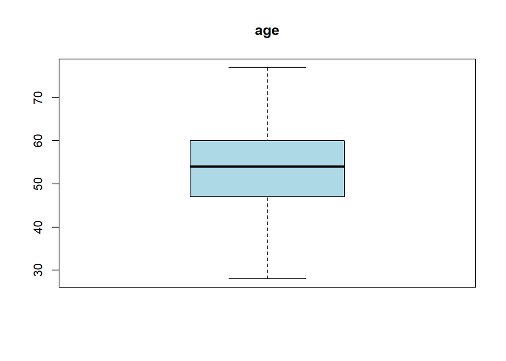

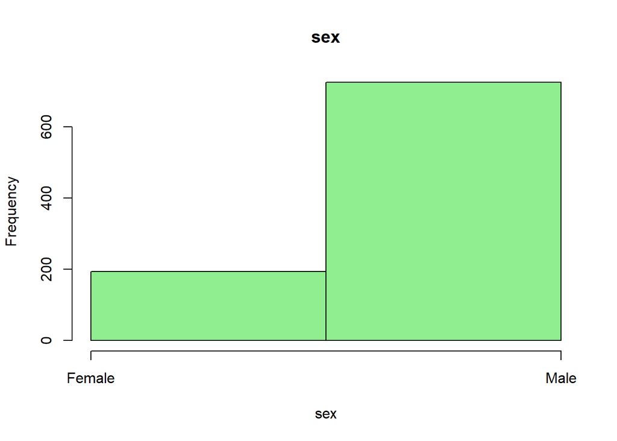

```
## [1] NA
```

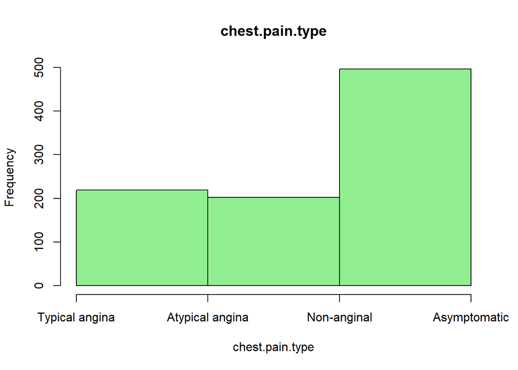

```
## [1] NA
```

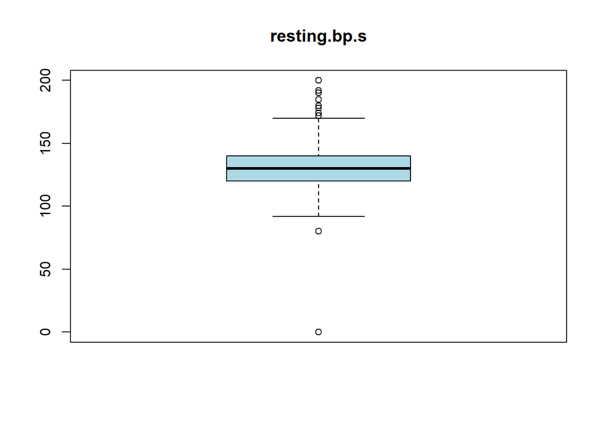

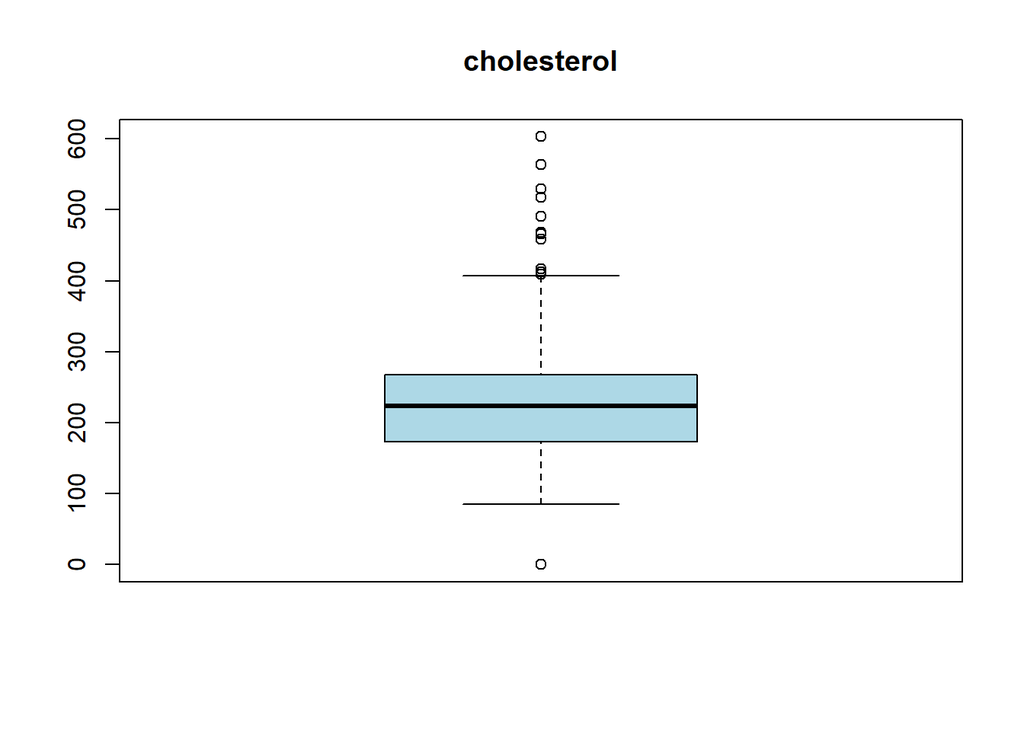

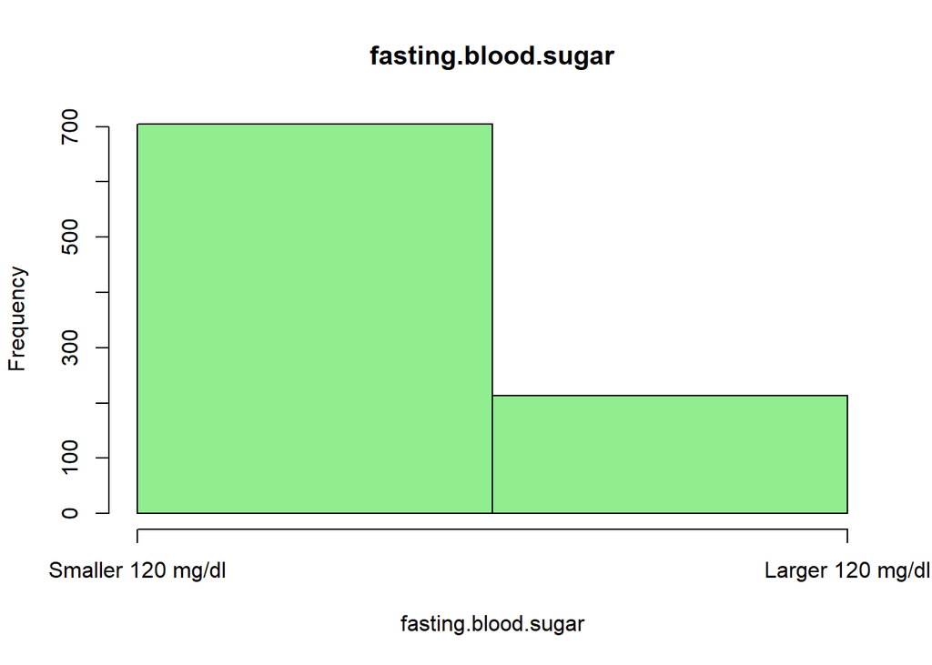

```
## [1] NA
```

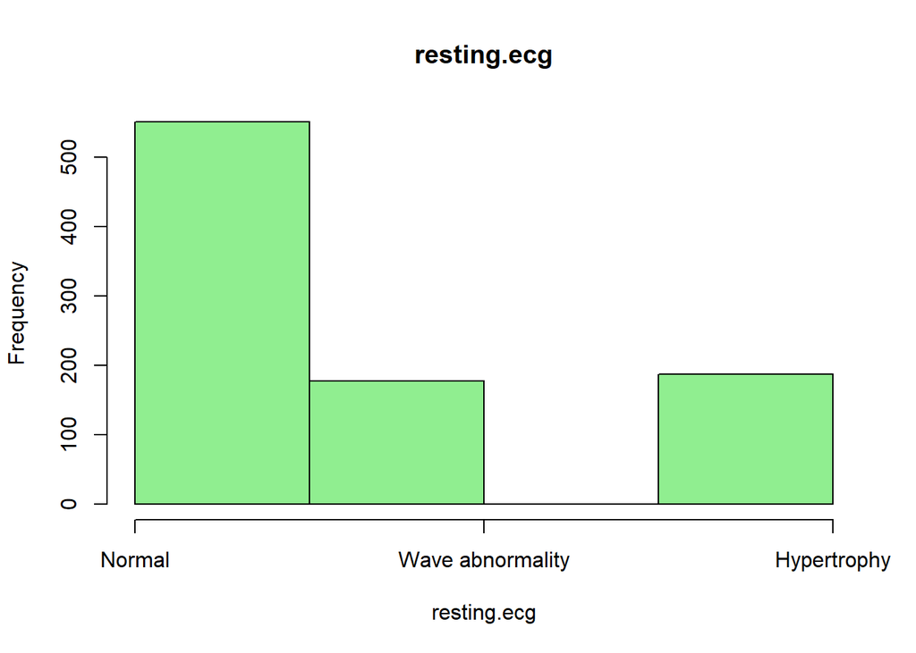

```
## [1] NA
```

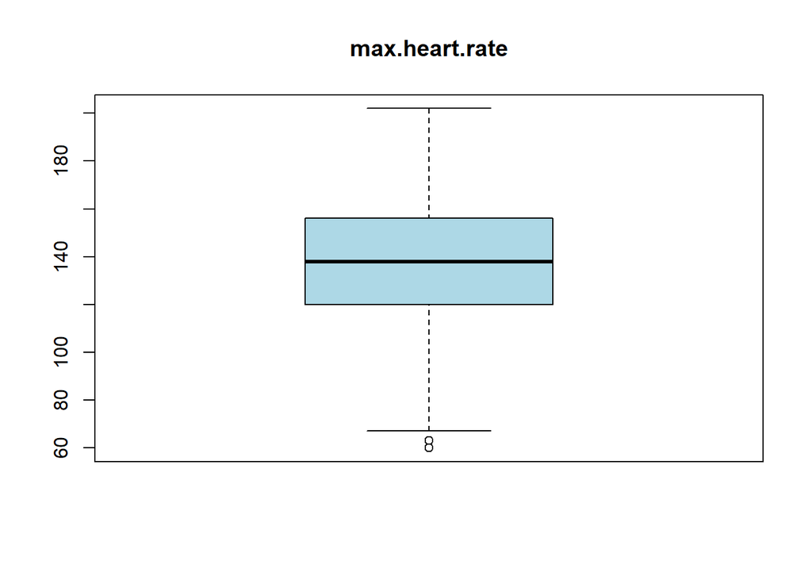

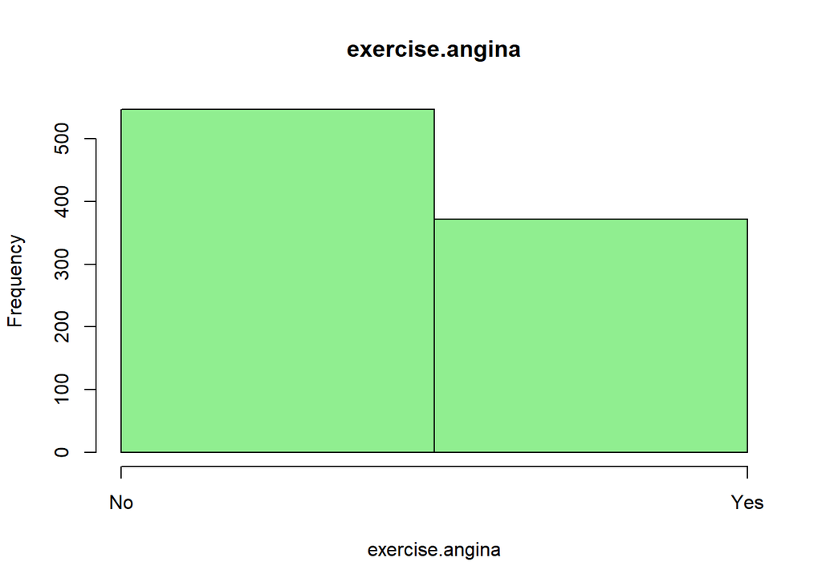

```
## [1] NA
```

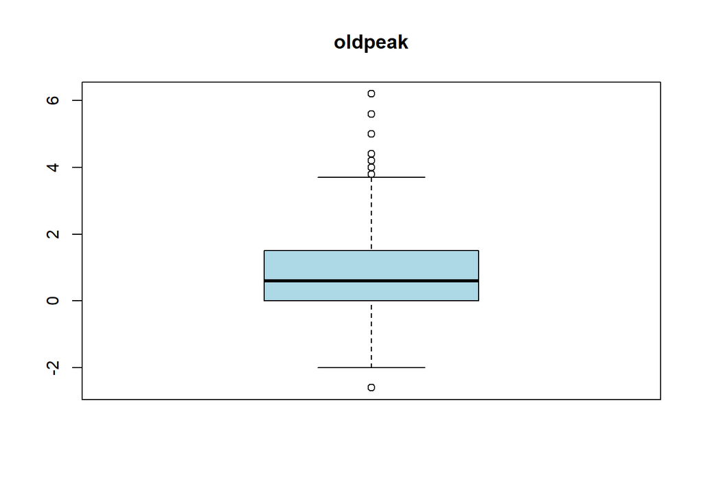

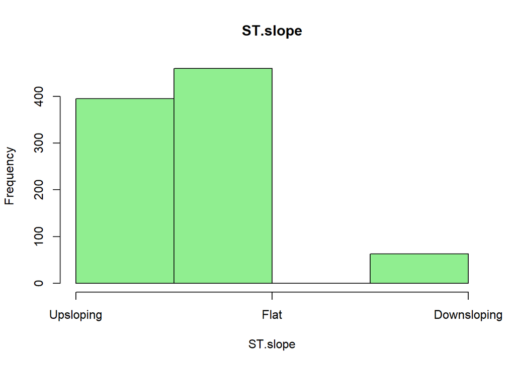

```
## [1] NA
```

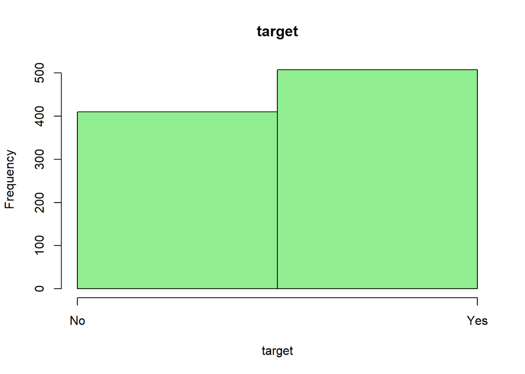

```
## [1] NA
```

```r
# let's examine for anomalies (no data analysis yet, just checking for data quality)
num_cols = ncol(df.cleaned)  # Total number of columns in the dataset

for (col in names(df.cleaned)) {

  if (is.numeric(df.cleaned[[col]])) {
    # Create boxplot for numeric variables
    boxplot(df.cleaned[[col]], main = col, col = "lightblue")
  } else if (is.factor(df.cleaned[[col]])) {
    hist(as.numeric(df.cleaned[[col]]), main = col, col = "lightgreen",
         breaks = length(levels(df.cleaned[[col]])), xaxt = "n", xlab=col)
    axis(1, at = 1:length(levels(df.cleaned[[col]])), labels = levels(df.cleaned[[col]]))
    print(NA)
  }
}
```

```r
# resting blood pressure and cholesterol have outliers at 0, which is near impossible in real life. Let's investigate.
bp_0 = sum(df.cleaned$resting.bp.s == 0)
chol_0 = sum(df.cleaned$cholesterol == 0)
cat("Number of data points with resting.bp.s == 0:", bp_0, "\n")
```

```
## Number of data points with resting.bp.s == 0: 1
```

```r
cat("Number of data points with cholesterol == 0:", chol_0, "\n")
```

```
## Number of data points with cholesterol == 0: 172
```

```r
# There are 172 entries where cholesterol is 0:) Nice. From this point we have 2 options:
# 1. drop rows with chol=0
# 2. impute based on the rest.
# let's quickly check correlation, to see if cholesterol depends on the rest (we will ofc drop zeroes)
df.cor_no_chol0 = df.cleaned[!(df.cleaned$cholesterol == 0 | df.cleaned$resting.bp.s == 0), ]
numeric_columns = df.cor_no_chol0[sapply(df.cor_no_chol0, is.numeric)]
cor_matrix = cor(numeric_columns, use = "complete.obs")
```

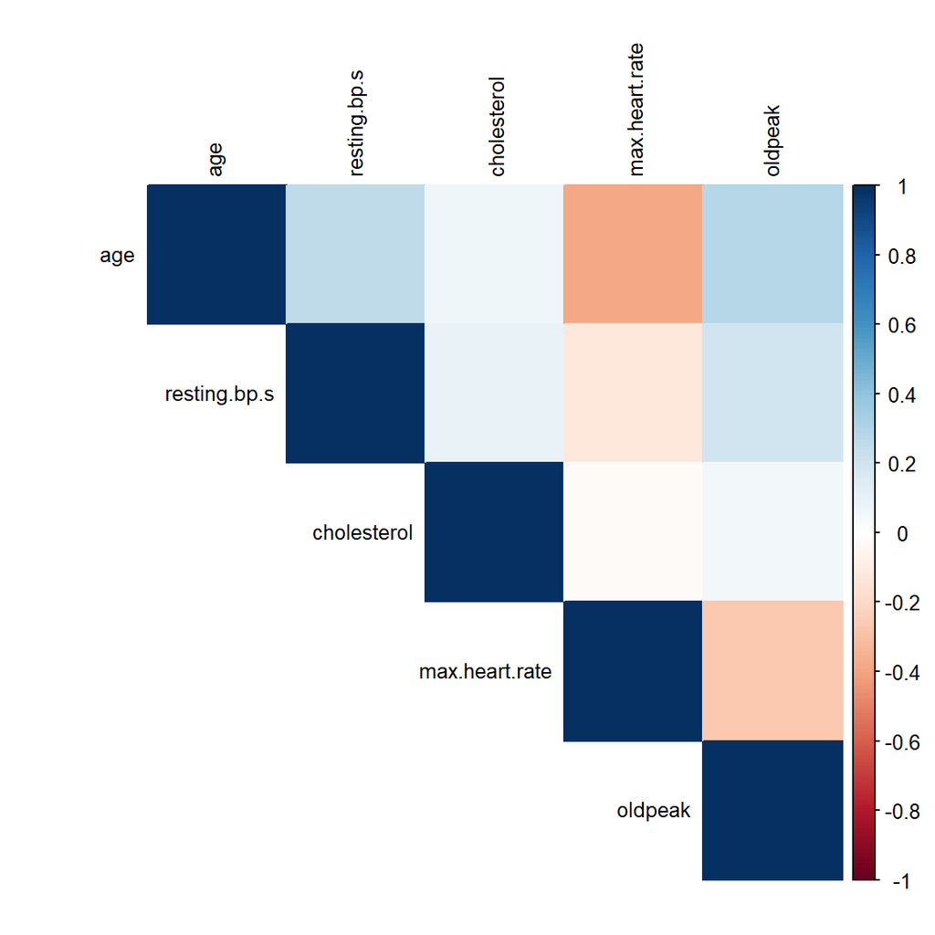

```r
corrplot(cor_matrix, method = "color", type = "upper", tl.col = "black", tl.cex = 0.8)
```

```r
# there is no correlation, just as i suspected, so deducing (imputing) chol from the rest of the variables is ifeasible. Ofc we can use other patients for imputation (trying to find combinations with similar values), but there are not enough variables for that (only 4 numeric besides cholesterol, the rest 6 are categorical with 2-4 values). Considering that we have more data than needed (11 predictors, almost 100 entries per predictor), the best solution would be to discard outliers with 0.

# we can now obtain our final dataset.
df.final = df.cleaned[!(df.cleaned$cholesterol == 0 | df.cleaned$resting.bp.s == 0), ]
# let's also rename target and move it to the first index position for clarity
names(df.final)[12] = "disease"
df.final = df.final[, c(ncol(df), 1:(ncol(df)-1))]
str(df.final)
```

```
## 'data.frame':    745 obs. of  12 variables:
##  $ disease            : Factor w/ 2 levels "No","Yes": 1 2 1 2 1 1 1 1 2 1 ...
##  $ age                : int  40 49 37 48 54 39 45 54 37 48 ...
##  $ sex                : Factor w/ 2 levels "Female","Male": 2 1 2 1 2 2 1 2 2 1 ...
##  $ chest.pain.type    : Factor w/ 4 levels "Typical angina",..: 2 3 2 4 3 3 2 2 4 2 ...
##  $ resting.bp.s       : int  140 160 130 138 150 120 130 110 140 120 ...
##  $ cholesterol        : int  289 180 283 214 195 339 237 208 207 284 ...
##  $ fasting.blood.sugar: Factor w/ 2 levels "Smaller 120 mg/dl",..: 1 1 1 1 1 1 1 1 1 1 ...
##  $ resting.ecg        : Factor w/ 3 levels "Normal","Wave abnormality",..: 1 1 2 1 1 1 1 1 1 1 ...
##  $ max.heart.rate     : int  172 156 98 108 122 170 170 142 130 120 ...
##  $ exercise.angina    : Factor w/ 2 levels "No","Yes": 1 1 1 2 1 1 1 1 2 1 ...
##  $ oldpeak            : num  0 1 0 1.5 0 0 0 0 1.5 0 ...
##  $ ST.slope           : Factor w/ 3 levels "Upsloping","Flat",..: 1 2 1 2 1 1 1 1 2 1 ...
```

```r
# for shiny apping latter, i will save the processed dataset, to not overcomplicate app logic.
saveRDS(df.final, file = "data.rds")
```

## Data analysis

Firstly, let’s make my favourite - pairplot:). It will help us to see most of the things we are iterested in initially: distributions, relationships, class separatation by pair-combinations of predictors.

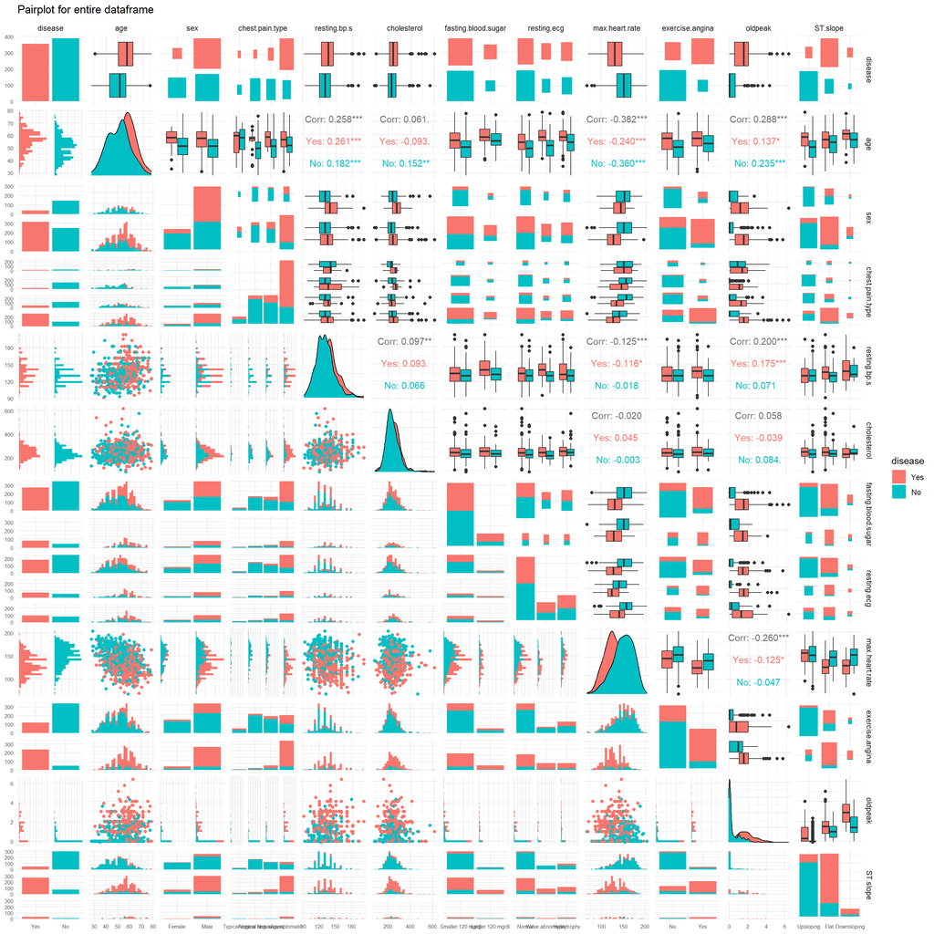

```r
pair_plot_entire_df = function(df) {
  plot_df = df
  # Reverse the levels of 'disease'
  plot_df$disease <- factor(df$disease, levels = c("Yes", "No"))
  ggpairs(plot_df,
          aes(color = disease),
          legend = 1) +
    theme_minimal() +
    labs(title = "Pairplot for entire dataframe") +
    theme(legend.position = "right", axis.text = element_text(size = 6), axis.title = element_text(size=6))
}

pair_plot_entire_df(df.final)
```

The pairplot is a rather big one, but it provides some useful insights. Firstly, we can observe demographics specifics: age approximately normally distributed around ~50 mean; most participants are males and the proportion of sick male patients is way higher (more than half of males got heart disease, compared to app. 1/3 of females). This could potentially indicate problems of the underlying studies, or mean that more males get a heart disease. Most importantly, there is no disbalance between target classes, which means we can proceed directly to machine learning. Besides demographics, it’s apparent that two classes are separated quite well for some combinations of parameters, leading to belief that the collection of variables at hand might provide enough separation power to clearly discern between target classes. There is way more to be said, but would be too much for the scope of such a small project. (Pairplots are like gold veins, they can provide many insights, that’s why they are my favorite).

Note: what is also important from the pairplot, is that all numerical variables except oldpeak are similar to normal distribution (hence, we could try z-scaling later). However, oldpeak is heavily skewed with a center mass near 0, so it cannot be z transformed (i have tested different transformation methods, but none could make it close to normal), so we will have to use robust scalling instead of z-transformation in the downstream pipeline. I later found out that glment does scaling internally, so the scalling part of the code was removed.

## Lasso regression for variable selection

```r
y = as.numeric(df.final$disease) - 1
x = model.matrix(disease~., data=df.final)[, -1]
```

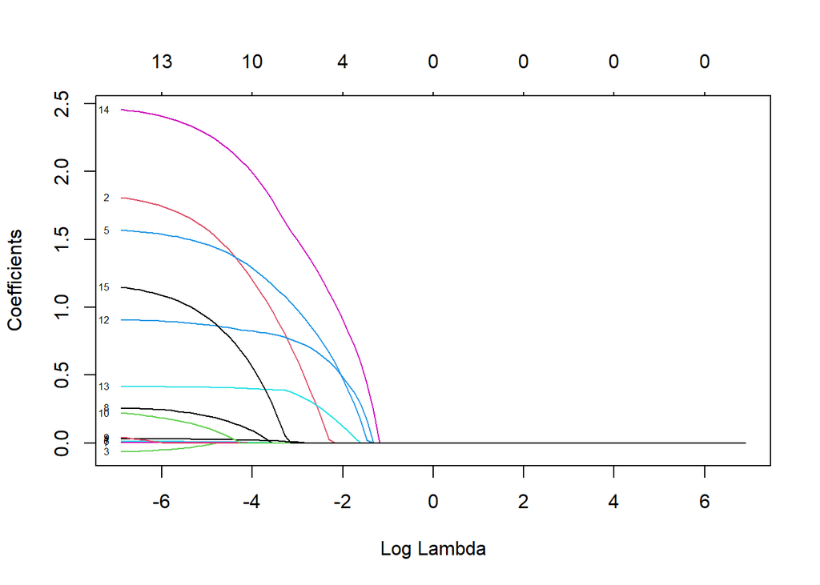

```r
grid = 10^seq(3, -3, length=100)
lasso = glmnet(x, y, alpha=1, lambda=grid, family="binomial")
plot(lasso, xvar = "lambda", label = TRUE)
```

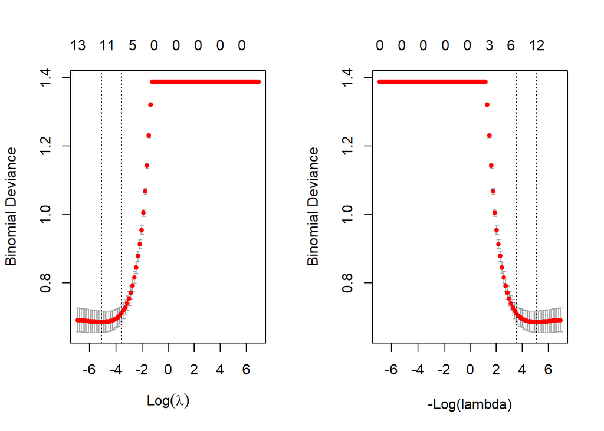

```r
# Tune lambda cross validating on the entire dataset
lasso.cv = cv.glmnet(x, y, alpha=1, lambda=grid, family="binomial")
par(mfrow = c(1, 2))
plot(lasso.cv)
plot(lasso.cv, sign.lambda=-1)
```

```r
lasso.max.par = lasso.cv$lambda.min
lasso.max.par.sd = lasso.cv$lambda.1se

results <- tibble(type = c("best lambda", "best lambda within 1sd of train error"),
n.par = rep(NA,2),
lambda = rep(NA,2),
predictors = list(NA, NA))

results$n.par[1] = sum(coef(lasso, s=lasso.max.par) != 0)
results$n.par[2] = sum(coef(lasso, s=lasso.max.par.sd) != 0)
results$lambda[1] = lasso.max.par
results$lambda[2] = lasso.max.par.sd

coef_min = coef(lasso, s = lasso.max.par)
nonzero_coef_indices = which(coef_min != 0)[-1]  # Exclude intercept
nonzero_predictors = rownames(coef_min)[nonzero_coef_indices]

# For lambda.1se
coef_1se = coef(lasso, s = lasso.max.par.sd)
nonzero_coef_indices_1se = which(coef_1se != 0)[-1]  # Exclude intercept
nonzero_predictors_1se = rownames(coef_1se)[nonzero_coef_indices_1se]

# Add predictors to results tibble
results$predictors[[1]] = nonzero_predictors
results$predictors[[2]] = nonzero_predictors_1se
```

```r
print(results)
```

```
## # A tibble: 2 × 4
##   type                                  n.par  lambda predictors
##   <chr>                                 <int>   <dbl> <list>
## 1 best lambda                              13 0.00614 <chr [12]>
## 2 best lambda within 1sd of train error     9 0.0285  <chr [8]>
```

```r
print("Best predictors with lambda")
```

```
## [1] "Best predictors with lambda"
```

```r
print(results$predictors[1])
```

```
## [[1]]
##  [1] "age"                                 "sexMale"
##  [3] "chest.pain.typeAtypical angina"      "chest.pain.typeAsymptomatic"
##  [5] "resting.bp.s"                        "cholesterol"
##  [7] "fasting.blood.sugarLarger 120 mg/dl" "resting.ecgHypertrophy"
##  [9] "exercise.anginaYes"                  "oldpeak"
## [11] "ST.slopeFlat"                        "ST.slopeDownsloping"
```

```r
print("Best predictors with 1sd lambda")
```

```
## [1] "Best predictors with 1sd lambda"
```

```r
print(results$predictors[2])
```

```
## [[1]]
## [1] "age"                         "sexMale"
## [3] "chest.pain.typeAsymptomatic" "resting.bp.s"
## [5] "exercise.anginaYes"          "oldpeak"
## [7] "ST.slopeFlat"                "ST.slopeDownsloping"
```

We can clearly see that the most important variables are age, type of chest pain, oldpeak, exercise angina pain, sex, resting blood pressure and slope of the ST. This subset of variables provides a compromise between train error and lambda (number of variables), hence - a trade-off between number of variables and model accuracy. I would prefer to use the smaller subset, as it clearly tells us the most important factors, while the larger subset (from the smallest lambda possible) might include unnecessary noise (predictors with low impact, which in practice might not be that relevant for the analysis in the medical industry). Hence, the smaller subset (corresponding to 1sd lambda) can be considered as main “indicators”, or “risk factors”. During validation we will check the performance difference between lambdas. Now, let’s see coefficients of the log regression model, corresponding to these variables, to understand their effect.

```r
coef(lasso.cv, s = "lambda.1se")
```

```
## 16 x 1 sparse Matrix of class "dgCMatrix"
##                                                s1
## (Intercept)                         -3.9182209819
## age                                  0.0160481514
## sexMale                              0.9736303907
## chest.pain.typeAtypical angina       .
## chest.pain.typeNon-anginal           .
## chest.pain.typeAsymptomatic          1.1650025002
## resting.bp.s                         0.0005043381
## cholesterol                          .
## fasting.blood.sugarLarger 120 mg/dl  .
## resting.ecgWave abnormality          .
## resting.ecgHypertrophy               .
## max.heart.rate                       .
## exercise.anginaYes                   0.8018386648
## oldpeak                              0.3926935430
## ST.slopeFlat                         1.7887486753
## ST.slopeDownsloping                  0.2857779558
```

These coefficients clearly indicate that increase in any of the variables would lead to higher risk of heart disease (all positive). This confirms my hypothesis that males are more likely to contract the disease, as sexMale has a positive regression coefficient. We can also see that higher age, higher resting blood pressure, asymptomatic chest pain, pain during exercises, oldpeak and flat/downsloping st slopes contribute positively to the risk of the heart disease. To not get too deep into the topic, we can just say that oldpeak and st.slope both refer to different parts of ECG(electrocardiogram) graph, so the final set of relevant predictors would be: 1. patient age 2. patient gender 3. presence of asymptomatic chest pain. 4. presence of angina pain during exercises. 5. ECG (st slope, oldpeak) 6. resting blood pressure. This effectively means that hospitals can only perform a single test (ECG) combined with patient in-take questionnaire (including measurements of blood pressure) to assess presence (and risks) of the heart disease.

Now, let’s obtain our final model (will be used in the shiny app). The model above obtained from cv is already final, but it is a part of cv object, so we will train it separately with best lambda (i will use 1sd lambda)

```r
lasso = glmnet(x, y, alpha=1, lambda=lasso.cv$lambda.1se, family="binomial")
```

## Validation

Let’s validate our methodology. We will do a classical test-train split for validation.

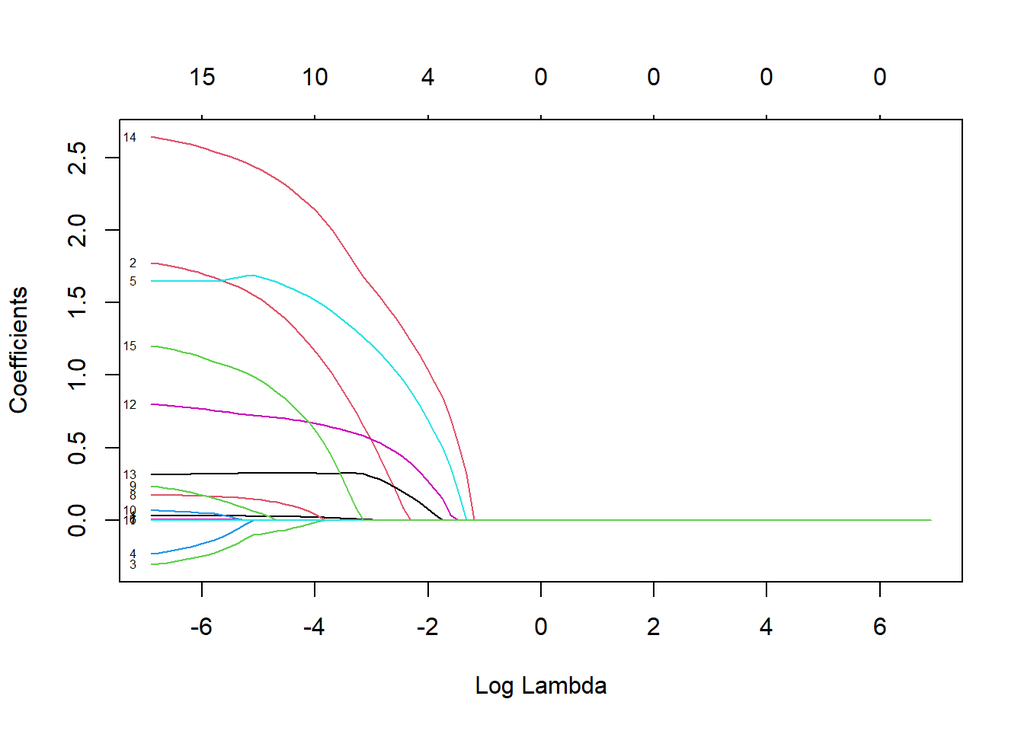

```r
train = sample(1:nrow(x), size=0.7*nrow(x))
x_train = x[train,]
x_test = x[-train,]
y_train = y[train]
y_test = y[-train]

grid = 10^seq(3, -3, length=100)
lasso = glmnet(x_train, y_train, alpha=1, lambda=grid, family="binomial")
plot(lasso, xvar = "lambda", label = TRUE)
```

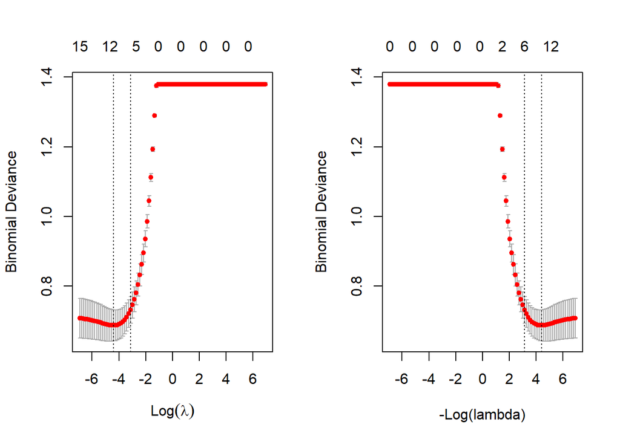

```r
lasso.cv = cv.glmnet(x_train, y_train, alpha=1, lambda=grid, family = "binomial")
par(mfrow = c(1, 2))
plot(lasso.cv)
plot(lasso.cv, sign.lambda=-1)
```

```r
lasso.max.par = lasso.cv$lambda.min
lasso.max.par.sd = lasso.cv$lambda.1se

lasso.pred = predict(lasso, s=lasso.max.par, newx=x_test, type="response")
lasso.pred.sd = predict(lasso, s=lasso.max.par.sd, newx=x_test, type="response")

lasso.class = ifelse(lasso.pred > 0.5, 1, 0)
lasso.class.sd = ifelse(lasso.pred.sd > 0.5, 1, 0)

results <- tibble(type = c("best lambda", "best lambda within 1sd of train error"),
error = rep(NA,2),
n.par = rep(NA,2),
lambda = rep(NA,2),
predictors = list(NA, NA))

results$error[1] = mean(lasso.class != y_test)
results$error[2] = mean(lasso.class.sd != y_test)
results$n.par[1] = sum(coef(lasso, s=lasso.max.par) != 0)
results$n.par[2] = sum(coef(lasso, s=lasso.max.par.sd) != 0)
results$lambda[1] = lasso.max.par
results$lambda[2] = lasso.max.par.sd

coef_min = coef(lasso, s = lasso.max.par)
nonzero_coef_indices = which(coef_min != 0)[-1]  # Exclude intercept
nonzero_predictors = rownames(coef_min)[nonzero_coef_indices]

# For lambda.1se
coef_1se = coef(lasso, s = lasso.max.par.sd)
nonzero_coef_indices_1se = which(coef_1se != 0)[-1]  # Exclude intercept
nonzero_predictors_1se = rownames(coef_1se)[nonzero_coef_indices_1se]

# Add predictors to results tibble
results$predictors[[1]] = nonzero_predictors
results$predictors[[2]] = nonzero_predictors_1se

print(results)
```

```
## # A tibble: 2 × 5
##   type                                  error n.par lambda predictors
##   <chr>                                 <dbl> <int>  <dbl> <list>
## 1 best lambda                           0.134    12 0.0123 <chr [11]>
## 2 best lambda within 1sd of train error 0.138     7 0.0433 <chr [6]>
```

```r
print("Best predictors with lambda")
```

```
## [1] "Best predictors with lambda"
```

```r
print(results$predictors[1])
```

```
## [[1]]
##  [1] "age"                                 "sexMale"
##  [3] "chest.pain.typeAtypical angina"      "chest.pain.typeAsymptomatic"
##  [5] "resting.bp.s"                        "cholesterol"
##  [7] "fasting.blood.sugarLarger 120 mg/dl" "exercise.anginaYes"
##  [9] "oldpeak"                             "ST.slopeFlat"
## [11] "ST.slopeDownsloping"
```

```r
print("Best predictors with 1sd lambda")
```

```
## [1] "Best predictors with 1sd lambda"
```

```r
print(results$predictors[2])
```

```
## [[1]]
## [1] "age"                         "sexMale"
## [3] "chest.pain.typeAsymptomatic" "exercise.anginaYes"
## [5] "oldpeak"                     "ST.slopeFlat"
```

But why do you use roc auc? It shows discrimination power between positive and negative instances across all thresholds, which is perfect for our use case. (helping doctors diagnosing/assessing risk of heart diseases). Plus it’s a nice way of having only one metric, instead of 4+.

```r
roc_min = roc(y_test, lasso.pred)
auc_min = auc(roc_min)

roc_1se = roc(y_test, lasso.pred.sd)
auc_1se = auc(roc_1se)

print(paste("AUC for best lambda:", auc_min))
```

```
## [1] "AUC for best lambda: 0.919011832427247"
```

```r
print(paste("AUC for best lambda within 1sd of train error:", auc_1se))
```

```
## [1] "AUC for best lambda within 1sd of train error: 0.912775823472977"
```

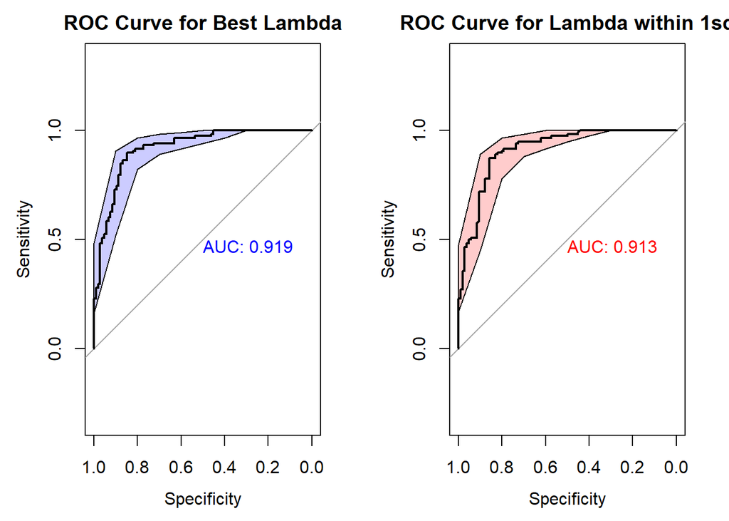

```r
par(mfrow = c(1, 2))
plot(roc_min, main = "ROC Curve for Best Lambda", col = "blue", print.auc=TRUE)
ci_min <- ci.se(roc_min, boot.n = 1000)
plot(ci_min, type = "shape", col = rgb(0, 0, 1, 0.2))
plot(roc_1se, main = "ROC Curve for Lambda within 1sd", col = "red", print.auc=TRUE)
ci_1se <- ci.se(roc_1se, boot.n = 1000)
plot(ci_1se, type = "shape", col = rgb(1, 0, 0, 0.2))
```

Firstly, the performance is excellent and consistent with training error (classification error) of around ~0.13-0.14 for 0.5 classification threshold. This means that our approach and model can easily distinguish between classes and the performance for the simpler model (6 predictors, 1sd train error lambda) is similar to that of the larger one. Furthermore, we can observe the same list of predictors: age, sex, exercise pain, chest pain asymptomatic, ECG (note that although I’ve set the same seed, different runs give slightly different predictor lists for lasso, mainly including or excluding age).